# Latihan Akhir TPG

DIANI RARAS PUSPITA

2025-12-03

## Bangkitkan Data

```r
# Contoh data MDS (15 objek)
data_example <- data.frame(
  Objek = paste0("Desa", sprintf("%02d", 1:15)),
  Region = c("Utara","Selatan","Pusat","Utara","Selatan","Pusat","Utara",
             "Selatan","Pusat","Utara","Selatan","Pusat","Utara","Selatan","Pusat"),
  income_percap = c(4200,3500,4800,2900,3300,2600,12000,3100,2700,3600, NA,4000,2300,3800,3400),
  education_index = c(62,55,70,48,52,45,95,50,46,57,54,60,40,58,53),
  sanitation_access = c(58,50,65,45,52,42,100,48,43,53,51,60,38,56,49),
  healthcare_index = c(50,45,60,40,47,38,95,44,39,49,46,55,35,52,46),
  pop_density = c(45,60,30,55,40,35,90,28,20,65,50,42,25,48, NA),
  vaccination_rate = c(58,50,68,46,52,44,98,48,42,55,51,62,38, NA,50),
  stringsAsFactors = FALSE
)

# Lihat data
print(data_example)
```

```
##     Objek  Region income_percap education_index sanitation_access
## 1  Desa01   Utara          4200              62                58
## 2  Desa02 Selatan          3500              55                50
## 3  Desa03   Pusat          4800              70                65
## 4  Desa04   Utara          2900              48                45
## 5  Desa05 Selatan          3300              52                52
## 6  Desa06   Pusat          2600              45                42
## 7  Desa07   Utara         12000              95               100
## 8  Desa08 Selatan          3100              50                48
## 9  Desa09   Pusat          2700              46                43
## 10 Desa10   Utara          3600              57                53
## 11 Desa11 Selatan            NA              54                51
## 12 Desa12   Pusat          4000              60                60
## 13 Desa13   Utara          2300              40                38
## 14 Desa14 Selatan          3800              58                56
```

[output cut: 17 more lines]

```r
str(data_example)
```

```
## 'data.frame':    15 obs. of  8 variables:
##  $ Objek            : chr  "Desa01" "Desa02" "Desa03" "Desa04" ...
##  $ Region           : chr  "Utara" "Selatan" "Pusat" "Utara" ...
##  $ income_percap    : num  4200 3500 4800 2900 3300 2600 12000 3100 2700 3600 ...
##  $ education_index  : num  62 55 70 48 52 45 95 50 46 57 ...
##  $ sanitation_access: num  58 50 65 45 52 42 100 48 43 53 ...
##  $ healthcare_index : num  50 45 60 40 47 38 95 44 39 49 ...
##  $ pop_density      : num  45 60 30 55 40 35 90 28 20 65 ...
##  $ vaccination_rate : num  58 50 68 46 52 44 98 48 42 55 ...
```

```r
summary(data_example)
```

```
##     Objek              Region          income_percap   education_index
##  Length:15          Length:15          Min.   : 2300   Min.   :40.00
##  Class :character   Class :character   1st Qu.: 2950   1st Qu.:49.00
##  Mode  :character   Mode  :character   Median : 3450   Median :54.00
##                                        Mean   : 4014   Mean   :56.33
##                                        3rd Qu.: 3950   3rd Qu.:59.00
##                                        Max.   :12000   Max.   :95.00
##                                        NA's   :1
##  sanitation_access healthcare_index  pop_density    vaccination_rate
##  Min.   : 38.0     Min.   :35.0     Min.   :20.00   Min.   :38.00
##  1st Qu.: 46.5     1st Qu.:42.0     1st Qu.:31.25   1st Qu.:46.50
##  Median : 51.0     Median :46.0     Median :43.50   Median :50.50
##  Mean   : 54.0     Mean   :49.4     Mean   :45.21   Mean   :54.43
##  3rd Qu.: 57.0     3rd Qu.:51.0     3rd Qu.:53.75   3rd Qu.:57.25
##  Max.   :100.0     Max.   :95.0     Max.   :90.00   Max.   :98.00
##                                     NA's   :1       NA's   :1
```

### Persiapan Paket

```r
set.seed(2025)
# Paket yang dipakai
if(!requireNamespace("smacof", quietly = TRUE)) install.packages("smacof")
if(!requireNamespace("ggplot2", quietly = TRUE)) install.packages("ggplot2")
library(smacof)
library(ggplot2)
```

### Cek Data Awal

```r
# tampilkan
print(data_example)
```

```
##     Objek  Region income_percap education_index sanitation_access
## 1  Desa01   Utara          4200              62                58
## 2  Desa02 Selatan          3500              55                50
## 3  Desa03   Pusat          4800              70                65
## 4  Desa04   Utara          2900              48                45
## 5  Desa05 Selatan          3300              52                52
## 6  Desa06   Pusat          2600              45                42
## 7  Desa07   Utara         12000              95               100
## 8  Desa08 Selatan          3100              50                48
## 9  Desa09   Pusat          2700              46                43
## 10 Desa10   Utara          3600              57                53
## 11 Desa11 Selatan            NA              54                51
## 12 Desa12   Pusat          4000              60                60
## 13 Desa13   Utara          2300              40                38
## 14 Desa14 Selatan          3800              58                56
```

[output cut: 17 more lines]

```r
str(data_example)
```

```
## 'data.frame':    15 obs. of  8 variables:
##  $ Objek            : chr  "Desa01" "Desa02" "Desa03" "Desa04" ...
##  $ Region           : chr  "Utara" "Selatan" "Pusat" "Utara" ...
##  $ income_percap    : num  4200 3500 4800 2900 3300 2600 12000 3100 2700 3600 ...
##  $ education_index  : num  62 55 70 48 52 45 95 50 46 57 ...
##  $ sanitation_access: num  58 50 65 45 52 42 100 48 43 53 ...
##  $ healthcare_index : num  50 45 60 40 47 38 95 44 39 49 ...
##  $ pop_density      : num  45 60 30 55 40 35 90 28 20 65 ...
##  $ vaccination_rate : num  58 50 68 46 52 44 98 48 42 55 ...
```

```r
summary(data_example)
```

```
##     Objek              Region          income_percap   education_index
##  Length:15          Length:15          Min.   : 2300   Min.   :40.00
##  Class :character   Class :character   1st Qu.: 2950   1st Qu.:49.00
##  Mode  :character   Mode  :character   Median : 3450   Median :54.00
##                                        Mean   : 4014   Mean   :56.33
##                                        3rd Qu.: 3950   3rd Qu.:59.00
##                                        Max.   :12000   Max.   :95.00
##                                        NA's   :1
##  sanitation_access healthcare_index  pop_density    vaccination_rate
##  Min.   : 38.0     Min.   :35.0     Min.   :20.00   Min.   :38.00
##  1st Qu.: 46.5     1st Qu.:42.0     1st Qu.:31.25   1st Qu.:46.50
##  Median : 51.0     Median :46.0     Median :43.50   Median :50.50
##  Mean   : 54.0     Mean   :49.4     Mean   :45.21   Mean   :54.43
##  3rd Qu.: 57.0     3rd Qu.:51.0     3rd Qu.:53.75   3rd Qu.:57.25
##  Max.   :100.0     Max.   :95.0     Max.   :90.00   Max.   :98.00
##                                     NA's   :1       NA's   :1
```

```r
# cek jumlah NA per kolom
colSums(is.na(data_example))
```

```
##             Objek            Region     income_percap   education_index
##                 0                 0                 1                 0
## sanitation_access  healthcare_index       pop_density  vaccination_rate
##                 0                 0                 1                 1
```

### Imputasi sederhana (median), ganti NA dengan median kolom

```r
numcols <- c("income_percap","education_index","sanitation_access",
             "healthcare_index","pop_density","vaccination_rate")

for(col in numcols){
  medval <- median(data_example[[col]], na.rm = TRUE)
  data_example[[col]][is.na(data_example[[col]])] <- medval
}

# cek ulang NA
colSums(is.na(data_example))
```

```
##             Objek            Region     income_percap   education_index
##                 0                 0                 0                 0
## sanitation_access  healthcare_index       pop_density  vaccination_rate
##                 0                 0                 0                 0
```

### Deteksi outlier (IQR) dan ringkasan, tampilkan indeks yang bermasalah

```r
outlier_idx <- list()
for(col in numcols){
  x <- data_example[[col]]
  Q1 <- quantile(x, 0.25)
  Q3 <- quantile(x, 0.75)
  IQRv <- Q3 - Q1
  lower <- Q1 - 1.5 * IQRv
  upper <- Q3 + 1.5 * IQRv
  out_idx <- which(x < lower | x > upper)
  outlier_idx[[col]] <- out_idx
}
outlier_idx
```

```
## $income_percap
## [1] 7
##
## $education_index
## [1] 7
##
## $sanitation_access
## [1] 7
##
## $healthcare_index
## [1] 7
##
## $pop_density
## [1] 7
##
## $vaccination_rate
## [1] 7
```

```r
# Lihat baris outlier unik
unique(unlist(outlier_idx))
```

```
## [1] 7
```

```r
# Lihat baris tersebut
data_example[unique(unlist(outlier_idx)), ]
```

```
##    Objek Region income_percap education_index sanitation_access
## 7 Desa07  Utara         12000              95               100
##   healthcare_index pop_density vaccination_rate
## 7               95          90               98
```

Desa07 muncul sebagai outlier di income_percap.

### Penanganan outlier(Winsorize)

```r
winsorize <- function(x, p = 0.05){
  lo <- quantile(x, p)
  hi <- quantile(x, 1 - p)
  x[x < lo] <- lo
  x[x > hi] <- hi
  x
}
# Terapkan hanya ke income_percap misalnya
data_w <- data_example
data_w$income_percap <- winsorize(data_w$income_percap, p = 0.05)

# Bandingkan sebelum & sesudah
data_example$income_percap
```

```
##  [1]  4200  3500  4800  2900  3300  2600 12000  3100  2700  3600  3450  4000
## [13]  2300  3800  3400
```

```r
data_w$income_percap
```

```
##  [1] 4200 3500 4800 2900 3300 2600 6960 3100 2700 3600 3450 4000 2510 3800 3400
```

Desa07 yang sebelumnya ekstrem sekarang masih “besar” tapi tidak terlalu ekstrim. Winsorize adalah cara konservatif untuk menangani outlier: tetap memasukkan informasi ekstrem tapi tidak merusak skala keseluruhan. MDS yang dijalankan setelah Winsorize akan lebih rapi, koordinat desa lain tidak terlalu terdorong jauh dari pusat cluster.

### Tetap gunakan data asli

```r
# tetap pakai data tanpa modifikasi:
data_w <- data_example
data_w
```

```
##     Objek  Region income_percap education_index sanitation_access
## 1  Desa01   Utara          4200              62                58
## 2  Desa02 Selatan          3500              55                50
## 3  Desa03   Pusat          4800              70                65
## 4  Desa04   Utara          2900              48                45
## 5  Desa05 Selatan          3300              52                52
## 6  Desa06   Pusat          2600              45                42
## 7  Desa07   Utara         12000              95               100
## 8  Desa08 Selatan          3100              50                48
## 9  Desa09   Pusat          2700              46                43
## 10 Desa10   Utara          3600              57                53
## 11 Desa11 Selatan          3450              54                51
## 12 Desa12   Pusat          4000              60                60
## 13 Desa13   Utara          2300              40                38
## 14 Desa14 Selatan          3800              58                56
```

[output cut: 17 more lines]

### Standarisasi (z-score)

```r
data_std <- as.data.frame(scale(data_w[ , numcols]))
rownames(data_std) <- data_w$Objek
# cek mean sd
round(colMeans(data_std), 4)
```

```
##     income_percap   education_index sanitation_access  healthcare_index
##                 0                 0                 0                 0
##       pop_density  vaccination_rate
##                 0                 0
```

```r
round(apply(data_std, 2, sd), 4)
```

```
##     income_percap   education_index sanitation_access  healthcare_index
##                 1                 1                 1                 1
##       pop_density  vaccination_rate
##                 1                 1
```

```r
head(data_std)
```

```
##        income_percap education_index sanitation_access healthcare_index
## Desa01    0.09659777       0.4346744         0.2738918       0.04211471
## Desa02   -0.20617137      -0.1022763        -0.2738918      -0.30884119
## Desa03    0.35611418       1.0483323         0.7532026       0.74402651
## Desa04   -0.46568778      -0.6392270        -0.6162567      -0.65979710
## Desa05   -0.29267684      -0.3323981        -0.1369459      -0.16845883
## Desa06   -0.59544598      -0.8693488        -0.8216755      -0.80017946
##         pop_density vaccination_rate
## Desa01 -0.005603255        0.2677394
## Desa02  0.834885042       -0.2910211
## Desa03 -0.846091553        0.9661900
## Desa04  0.554722276       -0.5704013
## Desa05 -0.285766021       -0.1513310
## Desa06 -0.565928787       -0.7100914
```

Interpretasi:

Desa01: Semua variabel mendekati rata-rata, sedikit lebih tinggi pada education_index dan sanitation_access.

Desa02: Income sedikit di bawah rata-rata, healthcare lebih rendah, tapi pop_density tinggi (lebih padat).

Desa03: Income, education, sanitation, healthcare di atas rata-rata, tapi pop_density lebih rendah (lebih jarang).

Desa04: Sebagian besar indikator di bawah rata-rata, tetapi pop_density agak tinggi → desa ini relatif padat tapi kondisi sosial-ekonomi kurang baik.

Desa06: Nilai terendah di hampir semua indikator, pop_density rendah → mungkin desa dengan kondisi sosial-ekonomi paling kurang.

### Hitung matriks jarak — Euclidean

```r
# Euclidean
dist_euc <- dist(data_std, method = "euclidean")
dist_euc
```

```
##            Desa01     Desa02     Desa03     Desa04     Desa05     Desa06
## Desa02  1.3497615
## Desa03  1.5364236  2.8652715
## Desa04  1.9418853  0.8675212  3.4194658
## Desa05  1.0987151  1.1722938  2.3484373  1.2154297
## Desa06  2.3150045  1.8491388  3.5122914  1.1861996  1.2800841
## Desa07  7.0852032  7.8124679  6.3912247  8.6379020  8.0848641  9.3135644
## Desa08  1.7649571  1.8534362  2.7339356  1.5685538  0.8249483  0.8785890
## Desa09  2.6056539  2.5177544  3.5025563  1.9946982  1.6486214  0.8621508
## Desa10  1.2792002  0.5889669  2.6843231  1.4058879  1.4813903  2.3693446
## Desa11  1.0525709  0.5786278  2.5293403  0.9027833  0.5968280  1.5007717
## Desa12  0.5284445  1.6956209  1.2554856  2.2397700  1.2585783  2.5234766
## Desa13  3.1167861  2.7036408  4.1750499  1.9836152  2.0797510  0.8791358
## Desa14  0.6820566  0.9660864  2.0592956  1.5064320  0.8177374  1.9710681
## Desa15  1.1722687  0.9432874  2.5270248  0.9692901  0.3359353  1.2015909
##            Desa07     Desa08     Desa09     Desa10     Desa11     Desa12
## Desa02
## Desa03
## Desa04
## Desa05
## Desa06
## Desa07
## Desa08  8.7459005
## Desa09  9.5746690  0.8608240
## Desa10  7.3117223  2.2611247  3.0012093
## Desa11  7.9027297  1.3200226  2.0601252  0.9511754
## Desa12  6.9369761  1.8928160  2.7489275  1.5459314  1.3559036
## Desa13 10.0988967  1.4464256  0.7709370  3.2358138  2.3613349  3.2941639
## Desa14  7.4408472  1.5394726  2.3478926  1.0516889  0.6522408  0.9531862
## Desa15  8.1405373  0.9316665  1.6841228  1.3394944  0.4032794  1.4253399
##            Desa13     Desa14
## Desa02
## Desa03
## Desa04
## Desa05
## Desa06
## Desa07
## Desa08
## Desa09
## Desa10
## Desa11
## Desa12
## Desa13
## Desa14  2.7736967
## Desa15  2.0399128  0.8055643
```

Kesimpulan

Cluster utama: Desa01, 02, 04, 05, 08, 09, 10, 11, 12, 14, 15 → jarak relatif kecil → profil mirip.

Outlier: Desa07 → profil sangat berbeda (income tinggi, fasilitas baik).

Posisi menengah: Desa03, Desa06, Desa13 → berbeda cukup jauh tapi tidak ekstrim.

MDS 2D/3D akan memvisualisasikan jarak ini, dengan cluster utama dekat dan Desa07 jauh di plot.

### Classical MDS (cmdscale) — 2 dimensi

```r
mds_classic <- cmdscale(dist_euc, k = 2, eig = TRUE)
coords_classic <- as.data.frame(mds_classic$points)
colnames(coords_classic) <- c("Dim1","Dim2")
coords_classic$Objek <- rownames(coords_classic)
coords_classic$Region <- data_w$Region

# Goodness of fit (prop var positif yang dijelaskan oleh 2 dim)
eigvals <- mds_classic$eig
gof <- sum(eigvals[1:2]) / sum(eigvals[eigvals > 0])
gof_text <- round(gof, 3)
gof_text
```

```
## [1] 0.986
```

2D Classical MDS cukup baik untuk visualisasi.

Plot 2D dapat digunakan untuk mendeteksi cluster desa dengan kondisi serupa dan mengidentifikasi outlier.

GOF yang tinggi (0.986) → interpretasi jarak dan kedekatan antar desa sangat akurat dalam 2D.

### Plot Classical MDS — base R & ggplot2

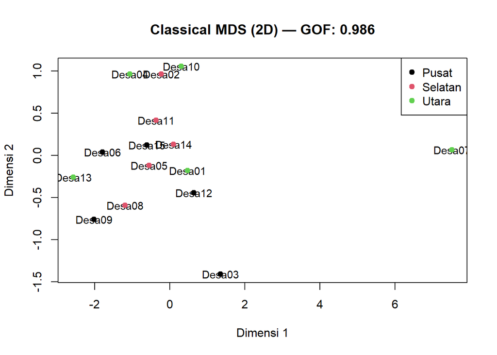

```r
# Base R
plot(coords_classic$Dim1, coords_classic$Dim2, type = "n",
     main = paste("Classical MDS (2D) — GOF:", gof_text),
     xlab = "Dimensi 1", ylab = "Dimensi 2")
text(coords_classic$Dim1, coords_classic$Dim2, labels = coords_classic$Objek, cex = 0.9)
points(coords_classic$Dim1, coords_classic$Dim2, pch = 19, col = as.numeric(factor(coords_classic$Region)))
legend("topright", legend = levels(factor(coords_classic$Region)), pch = 19, col = 1:length(levels(factor(coords_classic$Region))))
```

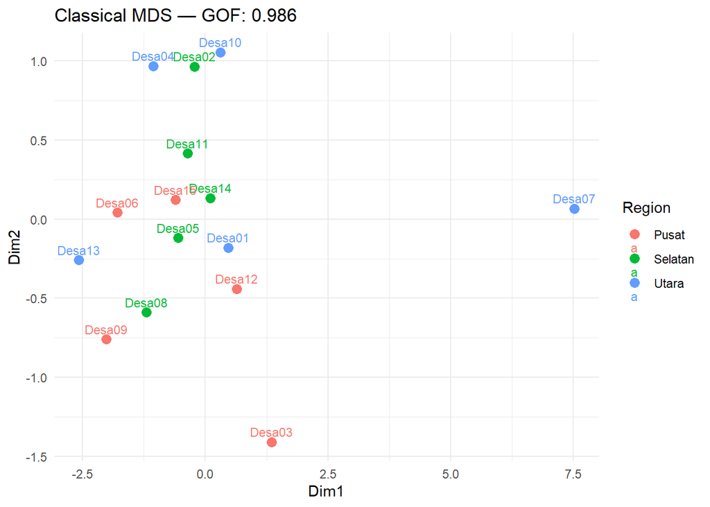

```r
# ggplot2 (lebih rapi)
ggplot(coords_classic, aes(x = Dim1, y = Dim2, color = Region, label = Objek)) +
  geom_point(size = 3) + geom_text(vjust = -0.6, size = 3) +
  ggtitle(paste("Classical MDS — GOF:", gof_text)) + theme_minimal()
```

Plot ini menunjukkan hasil Classical Multidimensional Scaling (MDS), yang bertujuan memvisualisasikan jarak atau disimilaritas antar objek (dalam hal ini, “Desa”) dalam ruang berdimensi rendah (dua dimensi, Dim1 dan Dim2). - Goodness of Fit (GOF): 0.986 Nilai GOF yang sangat tinggi ($0.986$) menunjukkan bahwa konfigurasi dua dimensi ini adalah representasi yang sangat baik dari matriks jarak/disimilaritas asli. Dengan kata lain, jarak antara titik-titik pada plot ini sangat akurat mencerminkan perbedaan atau kedekatan yang sebenarnya antara desa-desa tersebut. - Pola Pengelompokan (Klastering) Desa-desa dikelompokkan berdasarkan Region (Pusat, Selatan, Utara) yang diwakili oleh warna berbeda.Mayoritas desa tampakny berkumpul di kuadran kiri-atas (sekitar Dim1 -2.5 hingga 2.5, dan Dim2 -1.5 hingga 1.5). Ini menunjukkan bahwa, secara keseluruhan, desa-desa ini memiliki tingkat kesamaan yang relatif tinggi satu sama lain berdasarkan variabel yang diukur (yang menjadi dasar perhitungan jarak). - Pembeda UtamaDesa07 (Region Utara) menonjol sebagai pencilan (outlier) yang signifikan, berada sangat jauh di sisi kanan (sekitar Dim1 = 7.5). Hal ini menyiratkan bahwa Desa07 memiliki karakteristik yang sangat berbeda dari semua desa lainnya, jauh melebihi perbedaan antar region.Tidak ada pemisahan yang jelas berdasarkan warna (Region) di antara kelompok utama yang berkumpul di sebelah kiri. Desa dari Region Pusat, Selatan, dan Utara saling bercampur di area tersebut, menunjukkan bahwa variabel yang digunakan dalam MDS tidak secara kuat membedakan desa-desa hanya berdasarkan klasifikasi Region (kecuali Desa07).

```r
# smacofSym untuk non-metric
smacof_fit <- smacofSym(dist_euc, ndim = 2)
coords_smacof <- as.data.frame(smacof_fit$conf)
colnames(coords_smacof) <- c("Dim1","Dim2")
coords_smacof$Objek <- rownames(coords_smacof)
coords_smacof$Region <- data_w$Region

# Stress
stress_val <- smacof_fit$stress
stress_val_text <- round(stress_val, 4)
stress_val_text
```

```
## [1] 0.0112
```

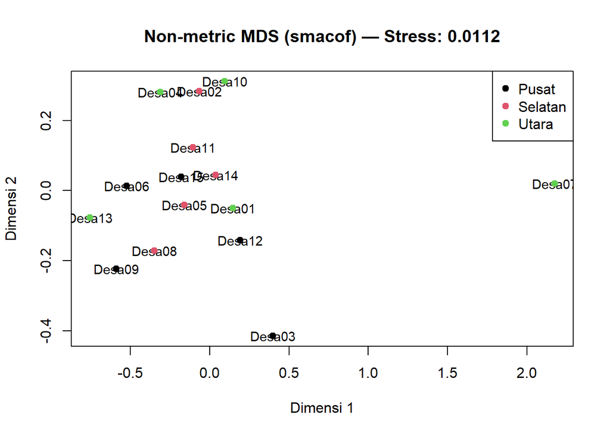

```r
# Plot smacof
plot(coords_smacof$Dim1, coords_smacof$Dim2, type = "n",
     main = paste("Non-metric MDS (smacof) — Stress:", stress_val_text),
     xlab = "Dimensi 1", ylab = "Dimensi 2")
text(coords_smacof$Dim1, coords_smacof$Dim2, labels = coords_smacof$Objek, cex = 0.9)
points(coords_smacof$Dim1, coords_smacof$Dim2, pch = 19, col = as.numeric(factor(coords_smacof$Region)))
legend("topright", legend = levels(factor(coords_smacof$Region)), pch = 19, col = 1:length(levels(factor(coords_smacof$Region))))
```